# 5 PCA

Published

November 7, 2025

## 5.1 PCA switch mice

Principal component analysis (PCA) of variance-stabilized RNA-seq counts from the switch cohort revealed that **tissue type** was the dominant driver of transcriptional variance. The first principal component (PC1), accounting for **98% of the total variance**, clearly separated **liver** and **brain** samples, indicating strong tissue-specific expression profiles. The second component (PC2), explaining about **1% of the variance**, captured minor within-tissue variability associated primarily with **sex**, with male and female samples forming partially distinct subclusters.

No obvious outliers were detected, and samples from independent batches overlapped within each tissue cluster, suggesting **minimal batch-related effects**. Together, these data confirm that tissue identity overwhelmingly dominates the transcriptional landscape in the switch mice.

### 5.1.1 All mice

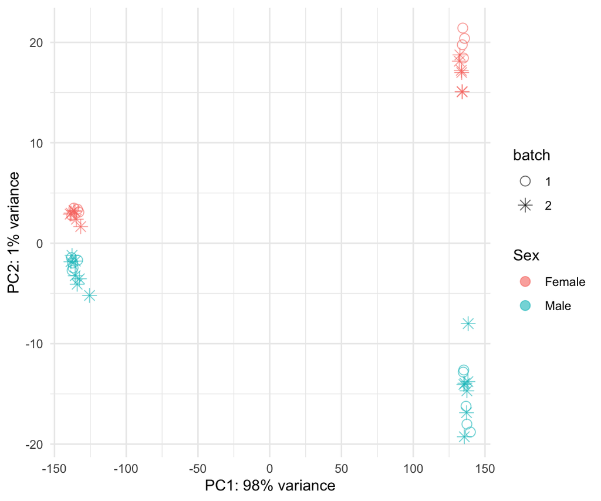

### 5.1.2 PCA by tissue and sex

Within each tissue–sex subgroup, **Cre-AAV** and **GFP control** mice formed partially overlapping clusters, suggesting that the switch introduced **subtle transcriptomic changes relative to the global tissue effect**.

Importantly, samples from **independent experimental batches** overlapped extensively, indicating that batch effects were minimal after normalization.

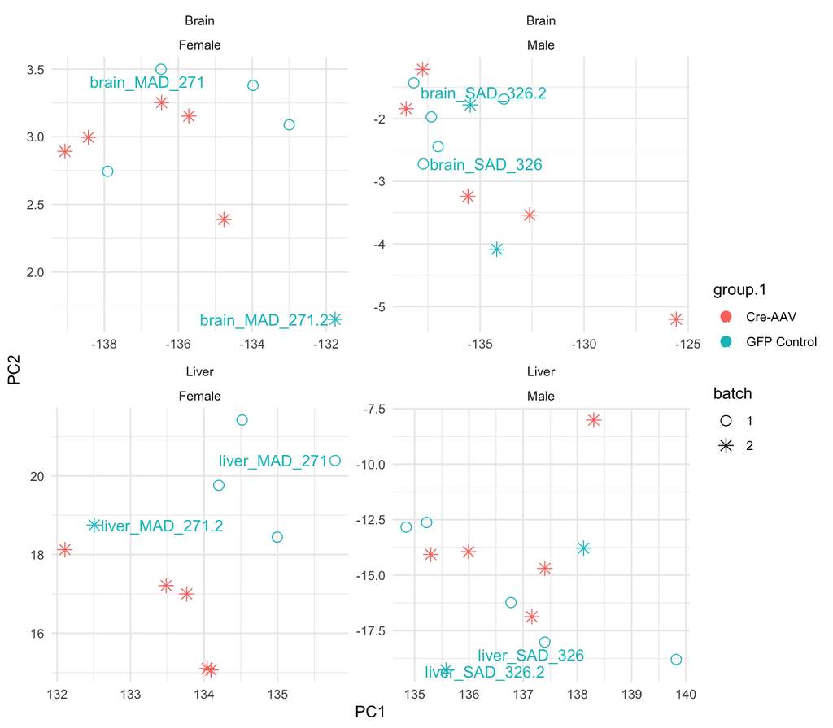

## 5.2 PCA TR mice

### 5.2.1 All TR mice

As occurred with switch mice, PCA of variance-stabilized RNA-seq counts from ApoE targeted-replacement (TR) mice revealed a strong separation of samples by **tissue type**, with **liver** and **brain** samples clearly segregating along the first principal component (PC1), which accounted for **98% of the total variance** .

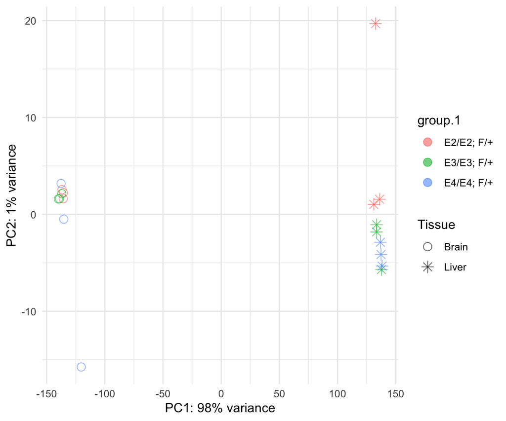

### 5.2.2 PCA by tissue with possible outliers labeled

Within the liver cluster, separation along the second principal component (PC2) distinguished **ApoE2/E2** mice from the **ApoE3/E3 and ApoE4/E4** groups . These data suggest that **ApoE2 expression has a more pronounced impact on liver transcriptomes** compared with the other ApoE isoforms, while tissue identity (liver vs. brain) remains the dominant source of variance across the dataset.

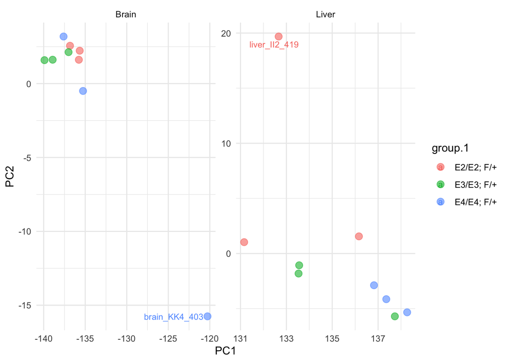